# Deep Learning — Assignment 8 — Score sheet

Eighth assignment for the 2024 Deep Learning course (NWI-IMC070) of the Radboud University.

Please enter your names and group number.**Names:**

**Group:**

## Objectives

In this assignment you will

1. Build a graph neural network, using pytorch geometric
2. Compare a GNN with other network architectures
3. Compare different GNN layers and aggregation functions

## Required software

As before you will need these libraries:

- `torch`, `torch-sparse`, `torch-scatter`, and `torch-geometric` for PyTorch,

The recommended way to install these libraries is described in the [torch-geometric installation instructions](https://pytorch-geometric.readthedocs.io/en/latest/notes/installation.html).

```python
# Replace ${TORCH} and ${CUDA} with your torch and cuda versions.
# Or remove the -f argument to compile from source
#
#!pip install torch-scatter torch-sparse -f https://data.pyg.org/whl/torch-${TORCH}+${CUDA}.html
#!pip install torch-geometric
```

```python
%config InlineBackend.figure_formats = ['png']
%matplotlib inline

import itertools
import numpy as np
import matplotlib.pyplot as plt
from IPython import display
import torch
import torch_geometric
from torch import nn
from torch.nn import functional as F
from torch_geometric.datasets import Planetoid
from torch_geometric.transforms import NormalizeFeatures
from torch_geometric.nn import GCNConv, SAGEConv, GraphConv

# Use the GPU if available
def detect_device():
    if torch.cuda.is_available():
        return torch.device("cuda")
    elif torch.backends.mps.is_available():
        return torch.device("mps")
    else:
        return torch.device("cpu")
device = detect_device()
```

```python
class Plotter:
    """For plotting data in animation."""
    # Based on d2l.Animator
    def __init__(self, xlabel=None, ylabel=None, legend=None, xlim=None,
                 ylim=None, xscale='linear', yscale='linear',
                 fmts=('-', 'm--', 'g-.', 'r:'), nrows=1, ncols=1,
                 figsize=(3.5, 2.5)):
        # Incrementally plot multiple lines
        if legend is None:
            legend = []
        self.fig, self.axes = plt.subplots(nrows, ncols, figsize=figsize)
        if nrows * ncols == 1:
            self.axes = [self.axes,]
        # Use a function to capture arguments
        def config_axes():
            axis = self.axes[0]
            axis.set_xlabel(xlabel), axis.set_ylabel(ylabel)
            axis.set_xscale(xscale), axis.set_yscale(yscale)
            axis.set_xlim(xlim),     axis.set_ylim(ylim)
            if legend:
                axis.legend(legend)
            axis.grid()
        self.config_axes = config_axes
        self.X, self.Y, self.fmts = None, None, fmts

    def add(self, x, y):
        # Add multiple data points into the figure
        if not hasattr(y, "__len__"):
            y = [y]
        n = len(y)
        if not hasattr(x, "__len__"):
            x = [x] * n
        if not self.X:
            self.X = [[] for _ in range(n)]
        if not self.Y:
            self.Y = [[] for _ in range(n)]
        for i, (a, b) in enumerate(zip(x, y)):
            if a is not None and b is not None:
                self.X[i].append(a)
                self.Y[i].append(b)
        self.axes[0].cla()
        for x, y, fmt in zip(self.X, self.Y, self.fmts):
            self.axes[0].plot(x, y, fmt)
        self.config_axes()
        display.display(self.fig)
        display.clear_output(wait=True)
```

## 8.1 A node classification dataset (1 point)

In this assignment we will be working on a node classification problem using the Citeseer dataset. This is a graph dataset that contains bag-of-words representation of documents and citation links between the documents. So there is an edge between document $i$ and document $j$ if one cites the other. This is an undirected edge.

```python
dataset = Planetoid(root='data', name='Citeseer', transform=NormalizeFeatures())
```

**8.1 a Add comment(a) How many graphs are there in this dataset? How large are they (in terms of nodes and edges)? (1 point)**

*Grading:*

- 1 point for the correct answer to all 3 questions (#graphs; #nodes; #edges).
- 0.5 point for missing 1 item.
- Printing the number of classes or features is not required.

```python
### BEGIN ANSWER
print(f'Dataset: {dataset}:')
print(f'Number of graphs: {len(dataset)}')
print(f'Number of features: {dataset.num_features}')
print(f'Number of classes: {dataset.num_classes}')
for i, data in enumerate(dataset):
    print(f'Graph {i}: Number of nodes: {data.num_nodes}')
    print(f'Graph {i}: Number of edges: {data.num_edges}')
### END ANSWER
```

```
Dataset: Citeseer():
Number of graphs: 1
Number of features: 3703
Number of classes: 6
Graph 0: Number of nodes: 3327
Graph 0: Number of edges: 9104
```

In fact, we will continue the rest of this notebook using the first graph from the dataset.

```python
data = dataset[0]  # Get the first graph object.
```

We will be use a subset of the nodes for training, and another subset for testing. These subsets are indicated by `data.train_mask` and `data.test_mask` respectively.

## 8.2 MLP for node classification (6 points)

In theory, we should be able to classify documents based only on their content, that is, using the bag-of-words features, without taking the graph structure into account.

We can verify that by constructing a simple node-wise multilayer perceptron with a single hidden layer. This network does not use the edge information at all.

**8.2 a Add comment(a) Complete the code below. (2 points)**

The network should have 2 linear layers. The hidden layer should have size `hidden_channels`, use ReLU activations, and use dropout with a dropout rate of 0.1. Don't use an activation function after the final layer.

Hint: avoid using `Sequential`, it will make the assignment harder later on.

*Grading:*

- 1 point for init, 1 point for forward.
- `forward` should not use `edge_index`
- Slightly different implementations are possible, but they should be equivalent to the code below.

```python
class MLP(torch.nn.Module):
    def __init__(self, num_features, num_classes, hidden_channels = 16):
        super().__init__()
        ### BEGIN ANSWER
        self.lin1 = nn.Linear(num_features, hidden_channels)
        self.lin2 = nn.Linear(hidden_channels, num_classes)
        ### END ANSWER

    def forward(self, x, edge_index):
        ### BEGIN ANSWER
        x = self.lin1(x)
        x = x.relu()
        x = F.dropout(x, p=0.1, training=self.training)
        x = self.lin2(x)
        return x
        ### END ANSWER
```

**8.2 b Add comment(b) Complete the training loop below. (2 points)**

Hint: compute the loss only on the training nodes.

Hint 2: `data.x` contains the features for each node, `data.y` contains their labels.

Hint 3: `model()` takes two parameters: a tensor of node features, and a tensor of edges. See the `test_accuracy` function.

*Grading:*

- 2 points for a correct implementation.
- 1 point with a single mistake (e.g. forgetting zero_grad, or wrong mask)

```python
def accuracy(pred_y, true_y):
    correct = pred_y.argmax(dim=1) == true_y
    return int(correct.sum()) / len(true_y)

def evaluate(model, data):
    loss_fn = torch.nn.CrossEntropyLoss()
    with torch.no_grad():
        model.eval()
        out = model(data.x, data.edge_index)
        # Compute loss and accuracy only on the 'test' nodes
        test_loss = loss_fn(out[data.test_mask], data.y[data.test_mask]).item()
        test_acc = accuracy(out[data.test_mask], data.y[data.test_mask])
        # Compute loss and accuracy only on the 'train' nodes
        train_loss = loss_fn(out[data.train_mask], data.y[data.train_mask]).item()
        train_acc = accuracy(out[data.train_mask], data.y[data.train_mask])
        return train_loss, train_acc, test_loss, test_acc

def train(model, data, lr=0.01, weight_decay=5e-4, num_epochs=400, plot=True):
    model = model.to(device)
    data = data.to(device)
    optimizer = torch.optim.Adam(model.parameters(), lr=lr, weight_decay=weight_decay)
    loss_fn = torch.nn.CrossEntropyLoss()
    if plot:
        plotter = Plotter(xlabel='epoch', xlim=[1, num_epochs], figsize=(10, 5),
                          legend=['train loss', 'train accuracy', 'test loss', 'test accuracy'])

    for epoch in range(1, num_epochs+1):
        model.train()
        ### BEGIN ANSWER
        optimizer.zero_grad()
        out = model(data.x, data.edge_index)
        loss = loss_fn(out[data.train_mask], data.y[data.train_mask])
        loss.backward()
        optimizer.step()
        ### END ANSWER

        # Compute test accuracy, and plot
        if plot and epoch % 10 == 0:
            train_loss, train_acc, test_loss, test_acc = evaluate(model, data)
            plotter.add(epoch + 1, (train_loss, train_acc, test_loss, test_acc))

    # Print final accuracy
    train_loss, train_acc, test_loss, test_acc = evaluate(model, data)
    print(f'Train loss: {train_loss:.4f}, Train accuracy: {train_acc:.4f}')
    print(f'Test loss: {test_loss:.4f}, Test accuracy: {test_acc:.4f}')
```

**8.2 c Add comment(c) Now construct and train an MLP on this dataset. (1 point)**

*Grading:*

- 1 point for a correct call.

```
Train loss: 0.0819, Train accuracy: 1.0000
Test loss: 1.2201, Test accuracy: 0.5910
```

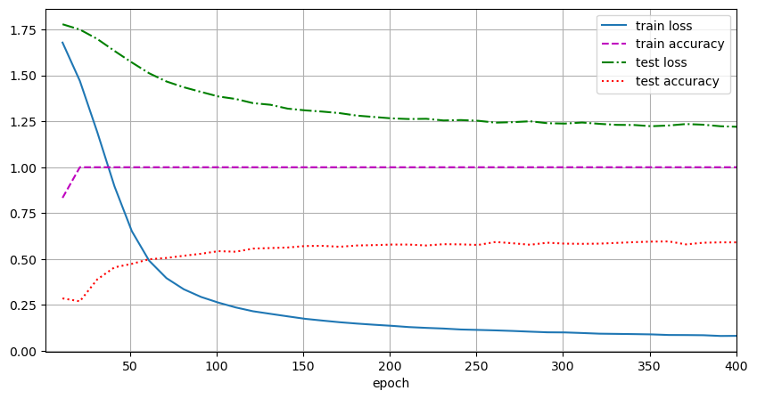

```python
### BEGIN ANSWER
mlp_model = MLP(dataset.num_features, dataset.num_classes, hidden_channels=16)
train(mlp_model, data)
### END ANSWER
```

**8.2 d Add comment(d) The MLP network does not use the citation information at all. Give a way to incorporate the edge information without using a graph neural network? (1 point)**

Note that the method should still work for arbitrary citation graphs.

Answer:

You could give information on the neighbors as extra features to each node. For example the number of neighbors, or the average neighbor feature values. Although the latter is already close to what graph neural networks do.

*Grading:*

- 1 points for a reasonable idea.
- 0 points for an answer that only works for networks with a fixed number of nodes.
- If you are unsure, ask on Discord.

## 8.3 A graph convolutional neural network (3 points)

Next, we will use a graph neural network based on the Graph Convolutional Network approach, which was introduced in the paper [Semi-Supervised Classification with Graph Convolutional Networks](https://arxiv.org/pdf/1609.02907.pdf).

**8.3 a Add comment(a) Implement a graph convolutional neural network, by replacing the linear layers in the MLP with [`GCNConv` layers](https://pytorch-geometric.readthedocs.io/en/latest/modules/nn.html#torch_geometric.nn.conv.GCNConv), and train the network. (1 point)**

The network should have two `GCNConv` layers. The rest of the architecture should stay as close as possible to the MLP.

*Grading:*

- 0.5 points for replacing Linear layers with GCNConv.
- 0.5 points for passing `edge_index` to layers.
- No points subtracted for mistakes already made in MLP

```
Train loss: 0.1808, Train accuracy: 1.0000
Test loss: 0.9402, Test accuracy: 0.7120
```

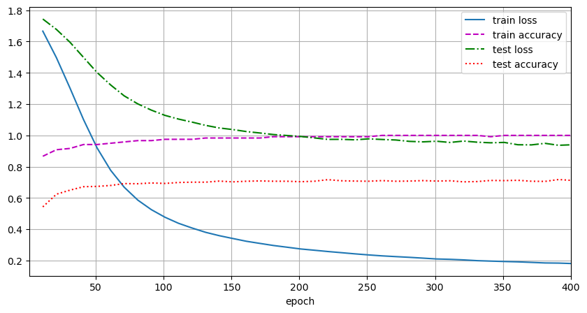

```python
class GCN(torch.nn.Module):
    def __init__(self, num_features, num_classes, hidden_channels = 16):
        super().__init__()
        ### BEGIN ANSWER
        self.conv1 = GCNConv(num_features, hidden_channels)
        self.conv2 = GCNConv(hidden_channels, num_classes)
        ### END ANSWER

    def forward(self, x, edge_index):
        ### BEGIN ANSWER
        x = self.conv1(x, edge_index)
        x = x.relu()
        x = F.dropout(x, p=0.1, training=self.training)
        x = self.conv2(x, edge_index)
        return x
        ### END ANSWER

### BEGIN ANSWER
gcn_model = GCN(dataset.num_features, dataset.num_classes, hidden_channels=16)
train(gcn_model, data)
### END ANSWER
```

**8.3 b Add comment(b) Compare the results of the MLP and the GCN. Which model is better? (1 point)**

Answer:

The GCN has a lower test loss and higher test accuracy. It is clearly better.

*Grading:*

- 1 point for a correct observation.
- If results of the experiments are different, then the answer here might be different and still correct. But this indicates a mistake was made above.

**8.3 c Add comment(c) Has the GCN training converged? Can you expect higher test accuracies by training longer? Explain your answer. (1 point)**

Answer:

The training and test loss are still going down, so training has not fully converged. But there is no change in the test accuracy for the last 200 epochs, so it is unlikely that that will improve by training longer.

*Grading:*

- 0.5 points for an answer about convergence.
- 0.5 points for an answer about training longer.
- The answer should look at both the loss and accuracy curves.

## 8.4 Comparing GNN layers (8 points)

Two graph layers that are interesting to compare are [`SAGEConv`](https://pytorch-geometric.readthedocs.io/en/latest/modules/nn.html#torch_geometric.nn.conv.SAGEConv) and [`GraphConv`](https://pytorch-geometric.readthedocs.io/en/latest/modules/nn.html#torch_geometric.nn.conv.GraphConv). Aside from one of them supporting weighted graphs, these models differ only in the accumulation function.

**8.4 a Add comment(a) Look at the documentation for these two layers. What is the difference in the accumulation function? (1 point)**

Answer:

SAGEConv uses the mean of the neighbors, GraphConv uses the sum.

*Grading:*

- 1 point for a correct answer. A more detailed explanation is not required.

To avoid having to copy the GNN structure every time, we can make our code generic in the type of layer to use.

**8.4 b Add comment(b) Make a generic graph neural network, that uses layers of type `layer_type`. (1 point)**

Hint: you can construct layers with `my_layer = layer_type(in_size, out_size, **layer_args)`.

*Grading:*

- 1 points for correct `__init__`.
- No points subtracted for mistakes already made in MLP or GCN.

```python
class GNN(torch.nn.Module):
    def __init__(self, layer_type, num_features, num_classes, hidden_channels=16, **layer_args):
        super().__init__()
        ### BEGIN ANSWER
        self.conv1 = layer_type(num_features, hidden_channels, **layer_args)
        self.conv2 = layer_type(hidden_channels, num_classes, **layer_args)
        ### END ANSWER

    def forward(self, x, edge_index):
        ### BEGIN ANSWER
        x = self.conv1(x, edge_index)
        x = x.relu()
        x = F.dropout(x, p=0.1, training=self.training)
        x = self.conv2(x, edge_index)
        return x
        ### END ANSWER
```

**(c) Train a SAGEConv network and a GraphConv network. (no points)**

*Grading:*

- No points, but check that the correct layer types are used.

```
Train loss: 0.0530, Train accuracy: 1.0000
Test loss: 0.9191, Test accuracy: 0.7070
```

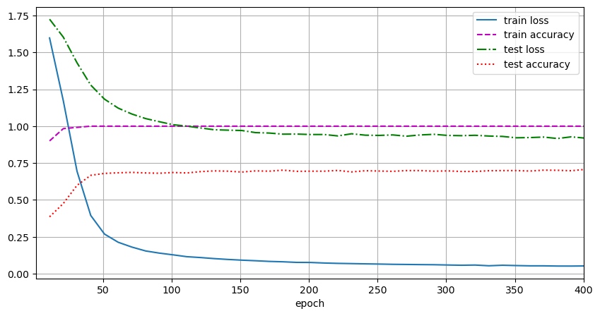

```python
### BEGIN ANSWER
sageconv_model = GNN(SAGEConv, dataset.num_features, dataset.num_classes, hidden_channels=16)
train(sageconv_model, data)
### END ANSWER
```

```
Train loss: 0.0238, Train accuracy: 1.0000
Test loss: 1.2984, Test accuracy: 0.6350
```

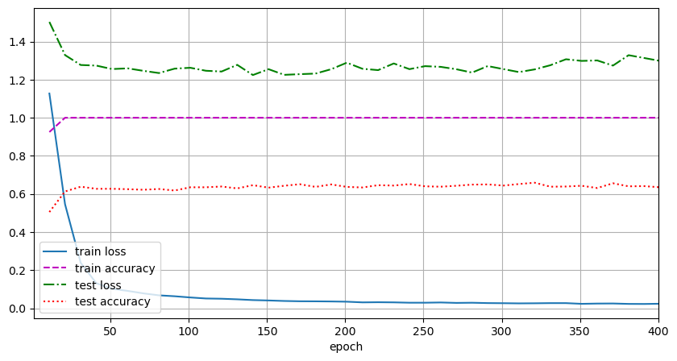

```python
### BEGIN ANSWER
graphconv_model = GNN(GraphConv, dataset.num_features, dataset.num_classes, hidden_channels=16)
train(graphconv_model, data)
### END ANSWER
```

**8.4 d Add comment(d) Compare the performance of these two models, and also compare them to the GCN. (1 point)**

Hint: look at the test loss.

Answer:

GraphConv performs worse than the other GNN models, it has a much higher test loss, and slightly lower test accuracy. SAGE is on par with GCN, although the results can differ somewhat between different runs.

*Grading:*

- 1 point for comparing all 3 models. The answer should at least mention accuracy, and ideally also the loss.
- 0.5 points if only 2 models are compared.
- Different answers are possible if the experiments give different results.

**8.4 e Add comment(e) Can you explain the observation in the previous question by looking at the aggregation functions? Why is one of them worse than the others? (1 point)**

Answer:

GraphConv uses the sum of the neighbors' vectors. If the number of neighbors differs, then the resulting value will also differ a lot. This big difference in values can be hard for the rest of the network to deal with.

*Grading:*

- 1 point for a correct argument about why 'sum' might be bad.

In fact, it is possible to use different aggregation functions, by passing `aggr=` to the network constructor.

**8.4 f Add comment(f) Compute the performance for `GraphConv` networks with `'mean'`, `'sum'`, `'min'`, `'max'`, and `'std'` aggregation. (1 point)**

Hint: train with `plot=False` to only show the final loss and accuracy.

Hint 2: if the performance is the same for all methods, there is most likely a bug in your `GNN` code.

*Grading:*

- 1 point for correct code doing these experiments.

```python
### BEGIN ANSWER
for aggr in ['mean','sum','min','max','std']:
    print(f'Aggregation: {aggr}')
    aggr_model = GNN(GraphConv, dataset.num_features, dataset.num_classes, hidden_channels=16, aggr=aggr)
    train(aggr_model, data, plot=False)
    print()
### END ANSWER
```

```
Aggregation: mean
Train loss: 0.0528, Train accuracy: 1.0000
Test loss: 0.9211, Test accuracy: 0.7000

Aggregation: sum
Train loss: 0.0239, Train accuracy: 1.0000
Test loss: 1.3704, Test accuracy: 0.6340

Aggregation: min
Train loss: 0.0458, Train accuracy: 1.0000
Test loss: 1.0305, Test accuracy: 0.6680

Aggregation: max
Train loss: 0.0345, Train accuracy: 1.0000
Test loss: 1.0389, Test accuracy: 0.6590

Aggregation: std
Train loss: 0.0730, Train accuracy: 1.0000
Test loss: 1.1573, Test accuracy: 0.6350
```

**8.4 g Add comment(g) Which three aggregation methods are the worst? For each one, explain why that one would not work well. (3 points)**

Hint: bag-of-word features are very sparse.

Answer:

`'sum'` has the problem explained in the answer for 8.4e: different number of neighbors can lead to very different feature values.

`'max'` performs about the same as `'min'`, because it also throws away a lot of useful information about word counts.

*Grading:*

- 1 point per aggregation method.
- 0 points if no explanation is given.
- It is possible that the bottom 3 is different with different runs. `'std'` and `'sum'` should always be in the bottom 3.

## 8.5 Discussion (3 points)

**8.5 a Add comment(a) We have split the data by picking some nodes for training, and some for testing. But the graph contains edges between training and testing nodes, so the training procedure has to use the entire graph, including test nodes. Is it possible for the model to cheat using leaked information about the test nodes? (1 point)**

Answer:

No, because the labels for the test nodes are not used during training.

*Grading:*

- 1 point for a correct answer.
- 0.5 points if no explanation is given.

**8.5 b Add comment(b) Can the GCN and GNN networks use information from neighbors of neighbors to classify a node? Briefly explain your answer. (1 point)**

Answer:

Yes. A graph conv layer incorporates information from neighbors. Since we have two of these layers, information on neighbors-of-neighbors can be used.

*Grading:*

- 1 point for a correct answer with explanation.
- 0.5 point for 'yes' without the correct explanation.

**8.5 c Add comment(c) Do you think the trained model will generalize to other graphs? Motivate your answer. (1 point)**

Answer:

Not really, the model is trained on only a single graph. Other graphs will likely have different characteristics in terms of number of neighbors, feature values, etc.

On the other hand, if the other graph is similar enough it could work. For example if both graphs are graphs of a single larger graph. The number of training nodes is larger than 1, so some generalization over nodes can be expected.

*Grading:*

- 1 point for a correct argument and motivation.
- You can make an argument for either 'yes' or 'no'. But the argument has to make sense. Ask on Discord if you are not sure.

## The end

Well done! Please double check the instructions at the top before you submit your results.

*This assignment has 21 points.* Version f8cf264 / 2024-10-21

## Score form

Something didn't work. Save the following list of scores in a text file and upload to Brightspace:

Download the scores as a text file